# Simple Linear Regression

```r
# Load your libraries
library(car)
library(tidyverse)
library(pander)
library(mosaic)
library(DT)
# Load your data after saving a csv file in your Data folder.
# You can use either
#   someName <- read.csv("../../Data/YourDataFileName.csv", header=TRUE)
# or
library(readr)
DataforLinearRegression <- read_csv('../../Data/DataforLinearRegression.csv')

#Don't forget to run "Session -> Set Working Directory -> To Source file location"
```

## House Prices in Denver, Colorado

### Introduction/Background

Colorado is a beautiful state, but are the prices of homes beautiful as well? Within the last couple of years, prices for homes have skyrocketed. Because of that, I have decided to conduct a linear regression analysis that compares home prices and square footage for houses in Denver, Colorado (with a sample of 30 houses). I gathered my information from a website called Zillow which showed me the houses for sale in Denver, Colorado along with the details of the house such as the square footage. I gathered a sample of 30 different homes from random communities.

### Question/Hypothesis

The question I am trying to answer is: How strong of a relationship is there between the price of a home and the square footage in Denver, Colorado?

The hypothesis below states that the slope is equal to zero. The alternative hypothesis states that the slope is not equal to zero.
$$H_0: \beta_1 = 0$$
$$H_a: \beta_1 \neq 0$$
Here is the significance level for this analysis: α=0.05

### Validation of the Model Appropriateness

```r
DenverH.lm <- lm(Home_Price ~ Square_Footage, data = DataforLinearRegression)
#par(mfrow=c(1,3))
```

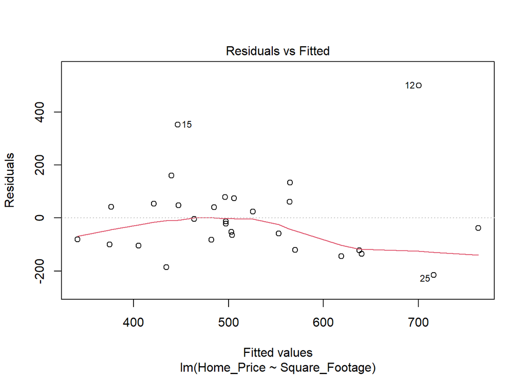

```r
plot(DenverH.lm, which=1)
```

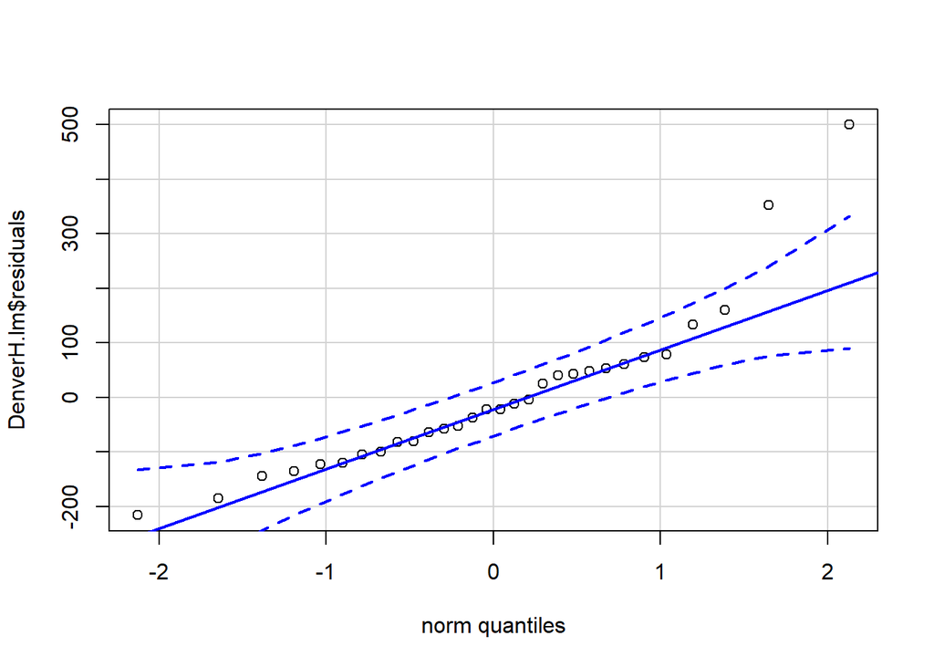

```r
qqPlot(DenverH.lm$residuals, id=FALSE)
```

The normality of the error terms can be checked through this QQPlot. It seems that most points are within the dashed boundary lines. There is only two points that are not. However, since it is only two points outside of the dashed boundary lines, the error terms are considered to be normal.

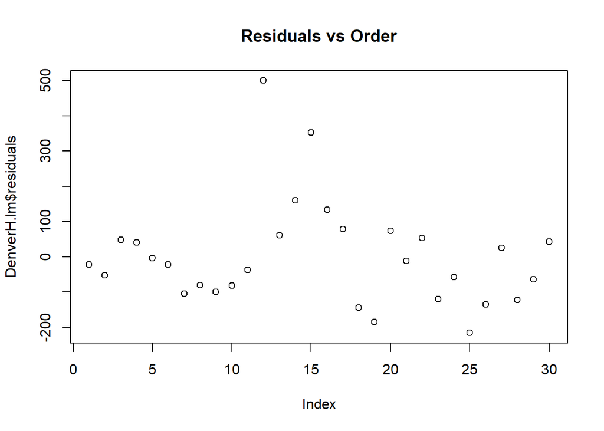

```r
plot(DenverH.lm$residuals, main="Residuals vs Order")
```

There seems to be a general trend. This means that the independence of the error terms is questionable.

### Linear Regression

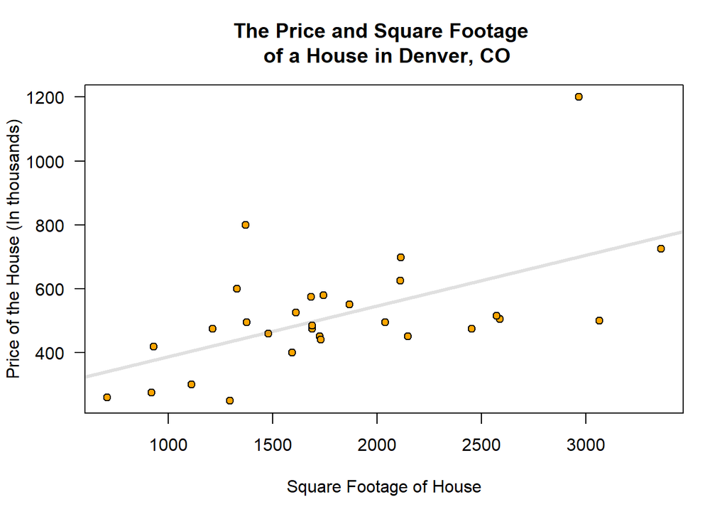

```r
plot(Home_Price ~ Square_Footage, data=DataforLinearRegression, pch=21, bg='orange', col='black',
     xlab='Square Footage of House', ylab='Price of the House (In thousands)',
     main='The Price and Square Footage \n of a House in Denver, CO', las=1)

DenverH.lm <- lm(Home_Price ~ Square_Footage, data=DataforLinearRegression)

abline(DenverH.lm, lwd=3, col=rgb(.4,.4,.4,.2))
abline(v=seq(40,120,20), h=seq(40,120,20), lty=2, col=rgb(.6,.6,.6,.2))
```

### Analysis Details

The equation of the fitted line shown in the plot above is:

$$\underbrace{\hat{Y}_i}_\text{Home Price} = \overbrace{b_0}^\text{est. y-int} + \overbrace{b_1}^\text{est. slope} \underbrace{X_i}_\text{Square Footage}$$

$$\text{Home Price} = 228,913.8 + 158.9 \times \text{(Square Footage)}$$

This is saying that for every additional square foot, the average price of a home in Denver,Co will go up by $158.9, essentially $159. This is the change in the average Y-value. The Y-intercept tells us the average Y-value when X is zero. In this case, when there is no square footage, the average price of a house in Denver, Co is $228,913.8. In other words, it is telling us the average price of a plot of land without a home, the average cost of the land being $228,913.8.

### Summary of the Regression

```r
summary(DenverH.lm) %>% pander()
```

|  | Estimate | Std. Error | t value | Pr(>\|t\|) |
| --- | --- | --- | --- | --- |
| **(Intercept)** | 228.9 | 83.21 | 2.751 | 0.0103 |
| **Square_Footage** | 0.1589 | 0.04348 | 3.655 | 0.001052 |

Fitting linear model: Home_Price ~ Square_Footage

| Observations | Residual Std. Error | $R^2$ | Adjusted $R^2$ |
| --- | --- | --- | --- |
| 30 | 151 | 0.323 | 0.2988 |

### Numerical Summary

```r
cor(DataforLinearRegression$Home_Price, DataforLinearRegression$Square_Footage) %>%
  pander()
```

*0.5683*

My numerical summary above shows the correlation between the price of a home in Denver, Co and the square footage. It appears we have a positive correlation. The strength of the two quantitative variables is not really strong or really week. It is around the middle in strength.

### The Data

Here is the data of the experiment.

```r
DataforLinearRegression1<-select(DataforLinearRegression, c('Square_Footage','Price'))

datatable(DataforLinearRegression1, options=list(lengthMenu = c(10,10,10)), extensions="Responsive")
```

|  | Square_Footage | Price |
| --- | --- | --- |
| 1 | 1689 | 475000 |
| 2 | 1724 | 450000 |
| 3 | 1374 | 495000 |
| 4 | 1610 | 525000 |
| 5 | 1479 | 459900 |
| 6 | 1689 | 475000 |
| 7 | 1110 | 300000 |
| 8 | 706 | 260100 |
| 9 | 919 | 275000 |
| 10 | 1593 | 400000 |

[output cut: 20 more lines]